# Hornbeck 6.14

## (a)

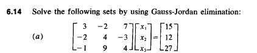

주어진 행렬 구성:

```python
import numpy as np

A = np.array([
    [3,-2,7],
    [-2,4,-3],
    [-1,9,4]
], dtype=np.float64)
b = np.array([15, 12, 27], dtype=np.float64).reshape(-1,1)
A, b
```

```
(array([[ 3., -2.,  7.],
        [-2.,  4., -3.],
        [-1.,  9.,  4.]]),
 array([[15.],
        [12.],
        [27.]]))
```

가우스-조던 소거법 함수 구현 및 시연:

```python
import numpy as np

augmented_matrix = np.hstack([A,b])

def Gauss_Jordan(augmented_matrix: np.array) -> tuple:
    n = augmented_matrix.shape[0] -1
    x = np.ones(n+1, dtype=np.float64)
    logs = []
    augmented_matrix = augmented_matrix.astype(np.float64)

    logs.append(f'Initial Matrix:\n{augmented_matrix}')
    for j in range(n+1):
        for i in range(n+1):
            if i!=j:
                c=augmented_matrix[i,j]/augmented_matrix[j,j]
                for k in range(n+2):
                    augmented_matrix[i,k]=augmented_matrix[i,k]-c*augmented_matrix[j,k]
            logs.append(f'Operation {j+1}:\n{augmented_matrix}')

    for i in range(n+1):
        x[i]=augmented_matrix[i,n+1]/augmented_matrix[i,i]

    return x, logs

x, logs = Gauss_Jordan(augmented_matrix=augmented_matrix)
print('\n'.join(logs))
print('Solution:', x)
```

```
Initial Matrix:
[[ 3. -2.  7. 15.]
 [-2.  4. -3. 12.]
 [-1.  9.  4. 27.]]
Operation 1:
[[ 3. -2.  7. 15.]
 [-2.  4. -3. 12.]
 [-1.  9.  4. 27.]]
Operation 1:
[[ 3.         -2.          7.         15.        ]
 [ 0.          2.66666667  1.66666667 22.        ]
 [-1.          9.          4.         27.        ]]
Operation 1:
[[ 3.         -2.          7.         15.        ]
 [ 0.          2.66666667  1.66666667 22.        ]
 [ 0.          8.33333333  6.33333333 32.        ]]
Operation 2:
[[ 3.          0.          8.25       31.5       ]
 [ 0.          2.66666667  1.66666667 22.        ]
 [ 0.          8.33333333  6.33333333 32.        ]]
Operation 2:
[[ 3.          0.          8.25       31.5       ]
 [ 0.          2.66666667  1.66666667 22.        ]
 [ 0.          8.33333333  6.33333333 32.        ]]
Operation 2:
[[  3.           0.           8.25        31.5       ]
 [  0.           2.66666667   1.66666667  22.        ]
 [  0.           0.           1.125      -36.75      ]]
Operation 3:
[[  3.           0.           0.         301.        ]
 [  0.           2.66666667   1.66666667  22.        ]
 [  0.           0.           1.125      -36.75      ]]
Operation 3:
[[ 3.00000000e+00  0.00000000e+00  0.00000000e+00  3.01000000e+02]
 [ 0.00000000e+00  2.66666667e+00  2.22044605e-16  7.64444444e+01]
 [ 0.00000000e+00  0.00000000e+00  1.12500000e+00 -3.67500000e+01]]
Operation 3:
[[ 3.00000000e+00  0.00000000e+00  0.00000000e+00  3.01000000e+02]
 [ 0.00000000e+00  2.66666667e+00  2.22044605e-16  7.64444444e+01]
 [ 0.00000000e+00  0.00000000e+00  1.12500000e+00 -3.67500000e+01]]
Solution: [100.33333333  28.66666667 -32.66666667]
```

```python
(A @ x.T).round(0) == b.T
```

```
array([[ True,  True,  True]])
```

정수로 반올림했을 때 문제의 $\vec{b}$(우변의 벡터)와 동일한 결과가 나왔다.

답:

$$ \begin{bmatrix} x_1\\x_2\\x_3 \end{bmatrix} = \begin{bmatrix} 100.333333...\\28.66666...\\-32.6666666... \end{bmatrix} $$

## (b)

행렬 구성:

```python
A = np.array([
    [2,-5,-9],
    [7,1,1],
    [-3,7,-1]
])
b = np.array([-4,8,2]).reshape(-1,1)
A, b
```

```
(array([[ 2, -5, -9],
        [ 7,  1,  1],
        [-3,  7, -1]]),
 array([[-4],
        [ 8],
        [ 2]]))
```

앞서 구현한 함수로 풀이:

```python
augmented_matrix = np.hstack([A,b])

# 가우스-조던 소거법
x, logs = Gauss_Jordan(augmented_matrix=augmented_matrix)

# 로그 출력
print("\n".join(logs))
print('Solution:', x)
```

```
Initial Matrix:
[[ 2. -5. -9. -4.]
 [ 7.  1.  1.  8.]
 [-3.  7. -1.  2.]]
Operation 1:
[[ 2. -5. -9. -4.]
 [ 7.  1.  1.  8.]
 [-3.  7. -1.  2.]]
Operation 1:
[[ 2.  -5.  -9.  -4. ]
 [ 0.  18.5 32.5 22. ]
 [-3.   7.  -1.   2. ]]
Operation 1:
[[  2.   -5.   -9.   -4. ]
 [  0.   18.5  32.5  22. ]
 [  0.   -0.5 -14.5  -4. ]]
Operation 2:
[[  2.           0.          -0.21621622   1.94594595]
 [  0.          18.5         32.5         22.        ]
 [  0.          -0.5        -14.5         -4.        ]]
Operation 2:
[[  2.           0.          -0.21621622   1.94594595]
 [  0.          18.5         32.5         22.        ]
 [  0.          -0.5        -14.5         -4.        ]]
Operation 2:
[[  2.           0.          -0.21621622   1.94594595]
 [  0.          18.5         32.5         22.        ]
 [  0.           0.         -13.62162162  -3.40540541]]
Operation 3:
[[ 2.00000000e+00  0.00000000e+00 -2.77555756e-17  2.00000000e+00]
 [ 0.00000000e+00  1.85000000e+01  3.25000000e+01  2.20000000e+01]
 [ 0.00000000e+00  0.00000000e+00 -1.36216216e+01 -3.40540541e+00]]
Operation 3:
[[ 2.00000000e+00  0.00000000e+00 -2.77555756e-17  2.00000000e+00]
 [ 0.00000000e+00  1.85000000e+01  0.00000000e+00  1.38750000e+01]
 [ 0.00000000e+00  0.00000000e+00 -1.36216216e+01 -3.40540541e+00]]
Operation 3:
[[ 2.00000000e+00  0.00000000e+00 -2.77555756e-17  2.00000000e+00]
 [ 0.00000000e+00  1.85000000e+01  0.00000000e+00  1.38750000e+01]
 [ 0.00000000e+00  0.00000000e+00 -1.36216216e+01 -3.40540541e+00]]
Solution: [1.   0.75 0.25]
```

```python
(A@x).round(0) == b.T
```

```
array([[ True,  True,  True]])
```

답:

$$ \begin{bmatrix} x_1\\x_2\\x_3 \end{bmatrix} = \begin{bmatrix} 1\\0.75\\0.25 \end{bmatrix} $$

# Hornbeck 6.17

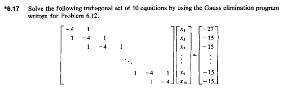

## 가우스 소거법

가우스 소거법(Gauss Elimination)으로 풀이하기 위해 **행렬 전체를 구성** 한다. 여기서부터 가우스 소거법의 비효율성을 직감할 수 있다.

```python
r1 = [[-4, 1] + [0 for _ in range(8)]]
r2_9 = [[0]* i + [1,-4,1] for i in range(0, 8)]
for idx in range(0, 8):
    r2_9[idx] = r2_9[idx] + [0 for j in range(7, idx, -1)]
r10 = [[0 for _ in range(8)] + [1,-4]]
A = np.array(r1 + r2_9 + r10)
A
```

```
array([[-4,  1,  0,  0,  0,  0,  0,  0,  0,  0],
       [ 1, -4,  1,  0,  0,  0,  0,  0,  0,  0],
       [ 0,  1, -4,  1,  0,  0,  0,  0,  0,  0],
       [ 0,  0,  1, -4,  1,  0,  0,  0,  0,  0],
       [ 0,  0,  0,  1, -4,  1,  0,  0,  0,  0],
       [ 0,  0,  0,  0,  1, -4,  1,  0,  0,  0],
       [ 0,  0,  0,  0,  0,  1, -4,  1,  0,  0],
       [ 0,  0,  0,  0,  0,  0,  1, -4,  1,  0],
       [ 0,  0,  0,  0,  0,  0,  0,  1, -4,  1],
       [ 0,  0,  0,  0,  0,  0,  0,  0,  1, -4]])
```

```python
b = np.array([-27] + [-15 for _ in range(9)]).reshape(-1,1)
b
```

```
array([[-27],
       [-15],
       [-15],
       [-15],
       [-15],
       [-15],
       [-15],
       [-15],
       [-15],
       [-15]])
```

```python
augmented_matrix = np.hstack([A, b])

x, logs = Gauss_Jordan(augmented_matrix=augmented_matrix)

# 로그 출력
print("\n".join(logs[-2:]))
print('Solution:', x)
```

```
Operation 10:
[[-4.00000000e+00  0.00000000e+00  0.00000000e+00  0.00000000e+00
   0.00000000e+00  0.00000000e+00  1.17958456e-20  3.14555883e-21
   0.00000000e+00  0.00000000e+00 -3.48230323e+01]
 [ 0.00000000e+00 -3.75000000e+00  0.00000000e+00  0.00000000e+00
   0.00000000e+00  0.00000000e+00  4.42344211e-20  1.17958456e-20
   0.00000000e+00  0.00000000e+00 -2.93363713e+01]
 [ 0.00000000e+00  0.00000000e+00 -3.73333333e+00  0.00000000e+00
   0.00000000e+00  0.00000000e+00  1.65141839e-19  4.40378237e-20
   0.00000000e+00  0.00000000e+00 -2.83224528e+01]
 [ 0.00000000e+00  0.00000000e+00  0.00000000e+00 -3.73214286e+00
   0.00000000e+00  0.00000000e+00  6.16332934e-19  1.64355449e-19
   0.00000000e+00  0.00000000e+00 -2.80748683e+01]
 [ 0.00000000e+00  0.00000000e+00  0.00000000e+00  0.00000000e+00
  -3.73205742e+00  0.00000000e+00  2.30018990e-18  6.13383973e-19
   0.00000000e+00  0.00000000e+00 -2.80032680e+01]
 [ 0.00000000e+00  0.00000000e+00  0.00000000e+00  0.00000000e+00
   0.00000000e+00 -3.73205128e+00  1.19606729e-16  2.28918044e-18
   0.00000000e+00  0.00000000e+00 -2.79579393e+01]
 [ 0.00000000e+00  0.00000000e+00  0.00000000e+00  0.00000000e+00
   0.00000000e+00  0.00000000e+00 -3.73205084e+00  1.19565640e-16
   0.00000000e+00  0.00000000e+00 -2.78477626e+01]
 [ 0.00000000e+00  0.00000000e+00  0.00000000e+00  0.00000000e+00
   0.00000000e+00  0.00000000e+00  1.19565640e-16 -3.73205081e+00
   0.00000000e+00  0.00000000e+00 -2.74523514e+01]
 [ 0.00000000e+00  0.00000000e+00  0.00000000e+00  0.00000000e+00
   0.00000000e+00  0.00000000e+00  3.18841707e-17  1.18993345e-16
  -3.73205081e+00  0.00000000e+00 -2.59808811e+01]
 [ 0.00000000e+00  0.00000000e+00  0.00000000e+00  0.00000000e+00
   0.00000000e+00  0.00000000e+00  7.97104268e-18  2.97483363e-17
   0.00000000e+00 -3.73205081e+00 -2.04904108e+01]]
Operation 10:
[[-4.00000000e+00  0.00000000e+00  0.00000000e+00  0.00000000e+00
   0.00000000e+00  0.00000000e+00  1.17958456e-20  3.14555883e-21
   0.00000000e+00  0.00000000e+00 -3.48230323e+01]
 [ 0.00000000e+00 -3.75000000e+00  0.00000000e+00  0.00000000e+00
   0.00000000e+00  0.00000000e+00  4.42344211e-20  1.17958456e-20
   0.00000000e+00  0.00000000e+00 -2.93363713e+01]
 [ 0.00000000e+00  0.00000000e+00 -3.73333333e+00  0.00000000e+00
   0.00000000e+00  0.00000000e+00  1.65141839e-19  4.40378237e-20
```

[output cut: 9 more lines]

```
   0.00000000e+00  0.00000000e+00 -2.79579393e+01]
 [ 0.00000000e+00  0.00000000e+00  0.00000000e+00  0.00000000e+00
   0.00000000e+00  0.00000000e+00 -3.73205084e+00  1.19565640e-16
   0.00000000e+00  0.00000000e+00 -2.78477626e+01]
 [ 0.00000000e+00  0.00000000e+00  0.00000000e+00  0.00000000e+00
   0.00000000e+00  0.00000000e+00  1.19565640e-16 -3.73205081e+00
   0.00000000e+00  0.00000000e+00 -2.74523514e+01]
 [ 0.00000000e+00  0.00000000e+00  0.00000000e+00  0.00000000e+00
   0.00000000e+00  0.00000000e+00  3.18841707e-17  1.18993345e-16
  -3.73205081e+00  0.00000000e+00 -2.59808811e+01]
 [ 0.00000000e+00  0.00000000e+00  0.00000000e+00  0.00000000e+00
   0.00000000e+00  0.00000000e+00  7.97104268e-18  2.97483363e-17
   0.00000000e+00 -3.73205081e+00 -2.04904108e+01]]
Solution: [8.70575808 7.82303234 7.58637127 7.52245276 7.50343976 7.4913063
 7.46178542 7.35583538 6.9615561  5.49038903]
```

```python
(A@x).round(0) == b.T
```

```
array([[ True,  True,  True,  True,  True,  True,  True,  True,  True,
         True]])
```

마찬가지로 정수로 반올림했을 때 우변의 $\vec{b}$와 일치한다.

따라서 가우스 소거법을 통한 답은 아래와 같다.

$$ \begin{bmatrix} x_1\\x_2\\x_3\\x_4\\x_5\\x_6\\x_7\\x_8\\x_9\\x_{10} \end{bmatrix} = \begin{bmatrix} 8.70575808 \\7.82303234\\ 7.58637127\\ 7.52245276\\ 7.50343976 \\7.4913063\\ 7.46178542\\ 7.35583538 \\6.9615561 \\ 5.49038903 \end{bmatrix} $$

## TDMA

TDMA로 풀 수 있는 삼대각 행렬 문제이므로, 문제의 요구사항은 아니지만 한 번 사용해보겠다.

```python
import numpy as np

n = 10
a = np.ones(n-1)  # 하부 대각선
b = -4 * np.ones(n)  # 주 대각선
c = np.ones(n-1)  # 상부 대각선
r = np.array([-27] + [-15]*(n-1))  # 우변 벡터
```

```python
import numpy as np

def TDMA(a:np.array, b:np.array, c:np.array, r:np.array) -> tuple:
    n = r.shape[0]-1
    x = np.zeros(n+1)
    logs = []
    a = a.astype(np.float64)
    b = b.astype(np.float64)
    c = c.astype(np.float64)
    r = r.astype(np.float64)

    # loop for the delet of lower diagonal terms in the tridiagonal matrix
    for i in range(1, n+1):
        factor = a[i-1]/b[i-1]
        b[i] = b[i] - factor * c[i-1]
        r[i] = r[i] - factor * r[i-1]
        logs.append(f'Row {i+1} Forward Elimination: \na={a}\nb={b}\nc={c}\nr={r}')

    x[n]=r[n]/b[n]
    # this loop is for backward substitution
    x[n] = r[n]/b[n]
    for i in range(n-1, -1, -1):
        x[i]=(r[i]-c[i]*x[i+1])/b[i]

    return logs, x

logs, x = TDMA(a, b, c, r)
print('\n'.join(logs[-2:]))
print('Solution:', x)
```

```
Row 9 Forward Elimination:
a=[1. 1. 1. 1. 1. 1. 1. 1. 1.]
b=[-4.         -3.75       -3.73333333 -3.73214286 -3.73205742 -3.73205128
 -3.73205084 -3.73205081 -3.73205081 -4.        ]
c=[1. 1. 1. 1. 1. 1. 1. 1. 1.]
r=[-27.         -21.75       -20.8        -20.57142857 -20.51196172
 -20.49615385 -20.49192717 -20.49079529 -20.49049205 -15.        ]
Row 10 Forward Elimination:
a=[1. 1. 1. 1. 1. 1. 1. 1. 1.]
b=[-4.         -3.75       -3.73333333 -3.73214286 -3.73205742 -3.73205128
 -3.73205084 -3.73205081 -3.73205081 -3.73205081]
c=[1. 1. 1. 1. 1. 1. 1. 1. 1.]
r=[-27.         -21.75       -20.8        -20.57142857 -20.51196172
 -20.49615385 -20.49192717 -20.49079529 -20.49049205 -20.4904108 ]
Solution: [8.70575808 7.82303234 7.58637127 7.52245276 7.50343976 7.4913063
 7.46178542 7.35583538 6.9615561  5.49038903]
```

```python
(A @ x.reshape(-1,1)).round(0)
```

```
array([[-27.],
       [-15.],
       [-15.],
       [-15.],
       [-15.],
       [-15.],
       [-15.],
       [-15.],
       [-15.],
       [-15.]])
```

아주 정확한 값이 나왔다.

# Hornbeck 6.21

가우스-지델 반복법으로 이전 문제의 삼대각행렬 방정식을 풀이해야 한다.

확장행렬 구성:

```python
r1 = [[-4, 1] + [0 for _ in range(8)]]
r2_9 = [[0]* i + [1,-4,1] for i in range(0, 8)]
for idx in range(0, 8):
    r2_9[idx] = r2_9[idx] + [0 for j in range(7, idx, -1)]
r10 = [[0 for _ in range(8)] + [1,-4]]
A = np.array(r1 + r2_9 + r10)
b = np.array([-27] + [-15 for _ in range(9)]).reshape(-1,1)
print(f'Augmented Matrix with the matrix A and vector b:\n{np.hstack([A,b])}')
```

```
Augmented Matrix with the matrix A and vector b:
[[ -4   1   0   0   0   0   0   0   0   0 -27]
 [  1  -4   1   0   0   0   0   0   0   0 -15]
 [  0   1  -4   1   0   0   0   0   0   0 -15]
 [  0   0   1  -4   1   0   0   0   0   0 -15]
 [  0   0   0   1  -4   1   0   0   0   0 -15]
 [  0   0   0   0   1  -4   1   0   0   0 -15]
 [  0   0   0   0   0   1  -4   1   0   0 -15]
 [  0   0   0   0   0   0   1  -4   1   0 -15]
 [  0   0   0   0   0   0   0   1  -4   1 -15]
 [  0   0   0   0   0   0   0   0   1  -4 -15]]
```

가우스-지델 반복법을 파이썬으로 옮긴 함수:

```python
import numpy as np

def gauss_seidel(A:np.array, b:np.array, epsilon:float, max_iter:int) -> tuple:
    """
    # Gauss-Seidel Iteration Method for solving linear equations Ax = b

    ## Parameters:
        **A (2D numpy array)**: Coefficient matrix
        **b (1D numpy array)**: Right-hand side vector
        **epsilon (float)**: Convergence tolerance
        **max_iter (int)**: Maximum number of iterations

    Returns:
        **x** 1D numpy array, Solution vector\\
        **iterations (int)**: Number of iterations performed
    """
    n = len(b)
    x = np.zeros(n)  # Initial guess for solution
    x_old = np.zeros(n)
    A = A.astype(np.float64)
    b = b.astype(np.float64)

    for j in range(max_iter):
        sum_new = 0.0
        sum_old = 0.0

        for i in range(n):
            sum_ = 0.0

            # Compute the sum excluding the current variable x[i]
            for k in range(n):
                if i != k:
                    sum_ -= A[i][k] * x_old[k]

            # Update the current variable x[i]
            x[i] = (sum_ + b[i]) / A[i][i]

            # Update sums for convergence check
            sum_new += x[i]
            sum_old += x_old[i]

            # Update the old solution with the new value
            x_old[i] = x[i]

        # Check convergence
        res = abs(sum_new - sum_old)
        print(f"Iteration #{j+1}")
        print(f"Sum Old: {sum_old}")
        print(f"Sum New: {sum_new}")
        print(f"Residual: {res}")

        if res < epsilon:
            break

    return x, j+1

x, num_iter = gauss_seidel(A, b, epsilon=1e-6, max_iter=100)
print(f'Solution vector:\n{x}\nThe Number of iterations:{num_iter}')
```

```
Iteration #1
Sum Old: 0.0
Sum New: 52.33333110809326
Residual: 52.33333110809326
Iteration #2
Sum Old: 52.33333110809326
Sum New: 67.38888520002365
Residual: 15.05555409193039
Iteration #3
Sum Old: 67.38888520002365
Sum New: 71.93402361497283
Residual: 4.545138414949179
Iteration #4
Sum Old: 71.93402361497283
Sum New: 73.31080792006105
Residual: 1.376784305088222
Iteration #5
Sum Old: 73.31080792006105
Sum New: 73.72604950162349
Residual: 0.41524158156244084
Iteration #6
Sum Old: 73.72604950162349
Sum New: 73.85027249811446
Residual: 0.12422299649097113
Iteration #7
Sum Old: 73.85027249811446
Sum New: 73.88701441084578
Residual: 0.03674191273131555
Iteration #8
Sum Old: 73.88701441084578
Sum New: 73.89771850515012
Residual: 0.01070409430434438
Iteration #9
Sum Old: 73.89771850515012
Sum New: 73.90077448972818
Residual: 0.0030559845780544492
Iteration #10
Sum Old: 73.90077448972818
Sum New: 73.90162294624511
Residual: 0.000848456516933993
```

[output cut: 9 more lines]

```
Sum Old: 73.90190725552849
Sum New: 73.90192177351457
Residual: 1.4517986087980717e-05
Iteration #14
Sum Old: 73.90192177351457
Sum New: 73.9019253237583
Residual: 3.550243732775016e-06
Iteration #15
Sum Old: 73.9019253237583
Sum New: 73.90192617858985
Residual: 8.548315406642359e-07
Solution vector:
[8.70575801 7.82303227 7.58637122 7.52245273 7.50343975 7.49130629
 7.46178542 7.35583538 6.9615561  5.49038903]
The Number of iterations:15
```

```python
((A @ x)).round(0) == b.T
```

```
array([[ True,  True,  True,  True,  True,  True,  True,  True,  True,
         True]])
```

마찬가지로 정수로 반올림했을 때 매우 정확한 값이 나왔다.